HOCHSCHULE RHEIN-WAAL  
RHINE-WAAL UNIVERSITY OF APPLIED SCIENCES  
FACULTY OF SOCIETY AND ECONOMICS  
COUNTRY DEVELOPMENT REPORT  
of Belarus, Jamaica, Peru,  
M-SD_1 7105: Quantitative Research Methods  
By  
MSD Student Amarachi Lauren Obioha  
32368  
Date:  
01.06.2023

# Country Development Report of: Belarus, Jamaica, Peru

# 1. Introduction

Obtain the data for all, in later problems required, variables for your three selected countries for the years 1980-2020 from the World Development Indicators-Database of the World Bank.

```r
library(WDI)
MyIndicators <- c("NY.GDP.MKTP.KD.ZG","NY.GDP.PCAP.PP.CD","SP.POP.TOTL","BX.KLT.DINV.WD.GD.ZS","SP.DYN.LE00.IN","SE.ENR.PRSC.FM.ZS","NE.TRD.GNFS.ZS","FP.CPI.TOTL.ZG","IT.NET.USER.ZS","DT.ODA.ALLD.CD")# <-- add all required indicators here!
??WDI
GDP<-WDIsearch("gdp")
Population <- WDIsearch("population")
FDI<-WDIsearch("Investment")
Health<- WDIsearch("life expectancy")
Education<-WDIsearch("enrollment")
Trade <- WDIsearch("trade")
Inflation <- WDIsearch("inflation")
Infrastructure<- WDIsearch("internet")
ODA<- WDIsearch("aid received")
```

As you will find missings (N/As) in your data, we impose spline interpolation per country and variable for obtaining a full dataset.

1. Describe the obtained dataset by tables of summary statistics for each country separately, including the mean, quartiles and standard deviation of all variables required below for the given/available timeframe for all countries separately.

#Rename the indicators

```r
WDI_renamed <- WDIfull %>%
  rename(GDP = NY.GDP.MKTP.KD.ZG,
         GDPperCapita = NY.GDP.PCAP.PP.CD,
         Trade = NE.TRD.GNFS.ZS,
         FDI = BX.KLT.DINV.WD.GD.ZS,
         Population = SP.POP.TOTL,
         ODA = DT.ODA.ALLD.CD,
         Inflation = FP.CPI.TOTL.ZG,
         Education = SE.ENR.PRSC.FM.ZS,
         Health = SP.DYN.LE00.IN,
         Infrastructure = IT.NET.USER.ZS)
```

##Grouped and summarized the data

```r
library(stargazer)
WDIBY<-WDI_renamed%>%
  filter(iso2c == "BY")
WDIBY<- as.data.frame(WDIBY)
stargazer(WDIBY, type ="text",iqr = T, title = "Descriptive statistics Belarus")
```

```
##
## Descriptive statistics Belarus
## =================================================================================================================
## Statistic      N       Mean          St. Dev.           Min           Pctl(25)       Pctl(75)           Max
## -----------------------------------------------------------------------------------------------------------------
## year           41    2,000.000        11.979           1,980           1,990           2,010           2,020
## GDP            41      1.234           7.344          -12.411          -3.830          7.043          11.450
## GDPperCapita   41    9,529.759       6,020.214       3,844.865       4,645.894      15,361.830      20,278.470
## Population     41  9,805,643.000    298,567.200      9,379,952       9,483,836      10,111,000      10,239,050
## FDI            41      1.735           1.435           0.041           0.708           2.473           6.481
## Health         41     70.475           1.834           67.907          68.912         71.483          74.227
## Education      41      0.989           0.012           0.976           0.978           0.996           1.010
## Trade          41     121.707         22.967           61.451         110.651         134.142         160.157
## Inflation      41     299.710         592.571          4.872           13.534         168.620        2,350.422
## Infrastructure 41     20.936          28.167          -0.0002          0.0005         31.800          85.088
## ODA            41 121,926,931.000 144,847,274.000 -250,169,998.000 50,612,499.000 186,009,995.000 825,799,988.000
## -----------------------------------------------------------------------------------------------------------------
```

```r
WDIJM<-WDI_renamed%>%
  filter(iso2c == "JM")
WDIJM<- as.data.frame(WDIJM)
stargazer(WDIJM, type ="text",iqr = T, title = "Descriptive statistics Jamaica")
```

```
##
## Descriptive statistics Jamaica
## ===============================================================================================================
## Statistic      N       Mean          St. Dev.          Min          Pctl(25)       Pctl(75)           Max
## ---------------------------------------------------------------------------------------------------------------
## year           41    2,000.000        11.979          1,980          1,990           2,010           2,020
## GDP            41      1.101          3.380          -10.000         -0.114          2.069           9.417
## GDPperCapita   41    7,175.438      1,612.324       4,816.160      6,079.212       8,431.375      10,676.730
## Population     41  2,560,105.000   206,661.000      2,135,546      2,392,030       2,733,896       2,820,436
## FDI            41      3.280          2.603          -0.517          1.405           5.341          10.041
## Health         41     71.504          0.923          69.435          70.888         72.124          73.433
## Education      41      1.028          0.019           1.002          1.013           1.037           1.070
## Trade          41     92.489          12.850         65.860          83.822         100.746         125.494
## Inflation      41     14.930          14.078          2.351          6.874          19.909          77.297
## Infrastructure 41     16.416          22.524         -0.003          0.035          27.670          79.432
## ODA            41 100,232,926.000 66,153,012.000 -17,230,000.000 43,750,000.000 152,279,999.000 271,579,987.000
## ---------------------------------------------------------------------------------------------------------------
```

```r
WDIPE<-WDI_renamed%>%
  filter(iso2c == "PE")
WDIPE<- as.data.frame(WDIPE)
stargazer(WDIPE, type ="text",iqr = T, title = "Descriptive statistics Peru")
```

```
##
## Descriptive statistics Peru
## ==================================================================================================================
## Statistic      N       Mean          St. Dev.           Min           Pctl(25)        Pctl(75)           Max
## ------------------------------------------------------------------------------------------------------------------
## year           41    2,000.000        11.979           1,980            1,990           2,010           2,020
## GDP            41      2.937           5.638          -12.312           1.495           6.285          12.308
## GDPperCapita   41    6,698.577       3,316.113       3,351.986        4,105.181       9,664.271      13,272.650
## Population     41 25,791,063.000   4,521,329.000     17,492,406      22,109,099      29,229,572      33,304,756
## FDI            41      2.658           2.267           -0.506           0.220           3.936           7.362
## Health         41     69.220           5.451           59.589          65.106          73.665          76.156
## Education      41      0.974           0.025           0.921            0.962           0.992           1.019
## Trade          41     40.483           9.304           22.537          33.206          47.514          58.434
## Inflation      41     315.819        1,266.258         0.193            2.768          73.528         7,481.664
## Infrastructure 41     16.590          20.469           -0.001           0.009          34.770          65.252
## ODA            41 365,118,536.000 164,667,113.000 -298,890,015.000 307,390,015.000 461,089,996.000 665,169,983.000
## ------------------------------------------------------------------------------------------------------------------
```

2. Calculate the GDP per capita (PPP) for all three countries and show its development from 1980 - 2020 in a single graph.

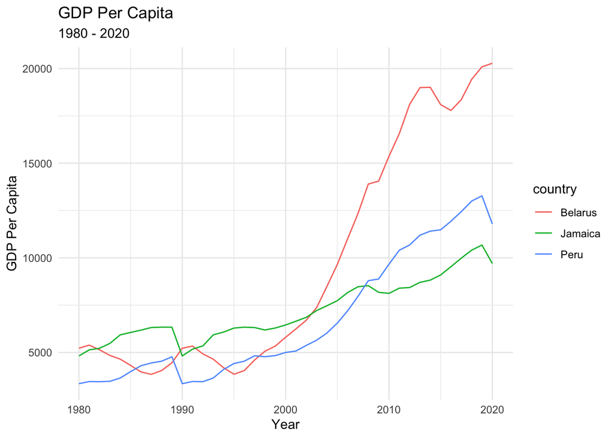

```r
library(ggplot2)
ggplot(WDI_renamed, aes(x = year, y = GDPperCapita, color = country)) +
  geom_line() +
  labs(x = "Year", y = "GDP Per Capita") +
  labs(title = "GDP Per Capita",
       subtitle = "1980 - 2020",
       x="Year", y = "GDP Per Capita") +
  theme_minimal()
```

**<The GDP per capita is already available in the World Development Indicators (WDI) data for Belarus, Jamaica and Peru as indicated in WDI_renamed which is why it is not calculated.>**

## Using this code to avoid scientific notation

```r
options(scipen = 999)
```

# 2. Determinants of Economic Development

From the literature we know that economic growth of a country is correlated with size of the labour force, investment, and involvement of the country in international trade. Moreover, it is often disputed that development aid makes a significant contribution. Thus, as model no. 1 (M1) run a pooled multiple linear regression (OLS) on the following equation:
$$(M1) \ \ \ GDP = \alpha +
\beta_1 Population + \beta_2 FDI + \beta_3 Trade + \beta_4 ODA + \beta_5
Inflation + \varepsilon$$
Find suitable variables that describe GDP, Population size, FDI (=Foreign Direct Investment), Trade (e.g. the degree of openness), ODA (Official Development Assistance). (M2) As model no. 2 estimate a log-linear version of M1. (M3) And a a log-log version of M1.

1. Present your regression results for all 3 models in a single table. Discuss which measure you would consult in order to find the model with the “best fit”. Explain what is meant by “best fit”.

```r
library(stargazer)
M1<-lm(GDP ~ Population + FDI + Trade + ODA + Inflation, data = WDI_renamed)
M2<-lm(log(GDP) ~ Population + FDI +  Trade + ODA + Inflation, data = WDI_renamed)
M3<-lm(log(GDP) ~ log(Population) + log(FDI) + log(Trade)+ log(ODA) + log(Inflation), data = WDI_renamed)
stargazer(M1, M2, M3,type="text")
```

```
##
## ======================================================================================
##                                            Dependent variable:
##                     ------------------------------------------------------------------
##                              GDP                            log(GDP)
##                              (1)                    (2)                   (3)
## --------------------------------------------------------------------------------------
## Population                0.00000**             0.00000***
##                           (0.00000)               (0.000)
##
## FDI                        0.496**                -0.066
##                            (0.222)                (0.042)
##
## Trade                       -0.004                0.007**
##                            (0.018)                (0.004)
##
## ODA                         -0.000                -0.000
##                            (0.000)                (0.000)
##
## Inflation                 -0.002***                0.002
##                            (0.001)                (0.001)
##
## log(Population)                                                        0.442***
##                                                                         (0.140)
##
## log(FDI)                                                                -0.021
##                                                                         (0.101)
##
## log(Trade)                                                               0.304
##                                                                         (0.279)
##
## log(ODA)                                                                 0.073
##                                                                         (0.156)
##
## log(Inflation)                                                          0.176**
##                                                                         (0.084)
##
## Constant                    0.447                  0.141               -8.977**
##                            (2.389)                (0.479)               (3.721)
##
## --------------------------------------------------------------------------------------
## Observations                 123                    89                    78
## R2                          0.219                  0.210                 0.247
## Adjusted R2                 0.185                  0.162                 0.194
## Residual Std. Error    5.150 (df = 117)       0.794 (df = 83)       0.810 (df = 72)
## F Statistic         6.548*** (df = 5; 117) 4.410*** (df = 5; 83) 4.712*** (df = 5; 72)
## ======================================================================================
## Note:                                                      *p<0.1; **p<0.05; ***p<0.01
```

__<##Interpretation The degree to which a model shows or depicts the underlying patterns and relationships in the data is referred to as the model’s “best fit” (Corbett, 2008). To determine the best, the R-squared would be considered as it indicates a better fit (Hill et al.,2018). R-squared shows how much of the variation in the dependent variable is accounted for by the model’s independent variables (Leatham,2012).It has a value between 0 and 1, with a greater value indicating best fit (Dancer & Tremayne, 2005).From the above observations and corresponding statistics, we can assess the “best fit” of three different models.

With an R-squared of 0.219 for the first model, it can be deduced that the independent variables account for around 21.9% of the variance in the dependent variable. The adjusted R-squared value, which takes the sample size and number of variables into consideration, is 0.185. With a residual standard error of 5.150, the F-statistic is 6.548.

The R-squared value for the second model is 0.210, which is a little less than that for the first model. The adjusted R-squared value is 0.162, showing that having more variables that predict or a smaller sample size reduces the model’s fit. Compared to the previous model, the residual standard error is significantly lower at 0.794 and the F-statistic is 4.410.

The R-squared value for the third model is 0.247, making it the highest of the three models. The R-squared value after adjustment is 0.194. Relative to the second model, the residual standard error is 0.810, which is slightly higher and the F-statistic is 4.712.

From the results, it can be concluded the third model has the highest R-squared value, indicating the best fit in terms of explaining the variation in the dependent variable.

NB:The number of observations in M1, M2 and M3 varies because of the presence of negative values.>__

2. Calculate 95%-confidence intervals for all coefficients of model M2. (Save the results in ‘MyRESULTS$P1b’.) Interpret the coefficients with respect to their effects (size, sign and significance) on the dependent variable.

```r
confint_M2 <- confint(M2, level = 0.95)
MyRESULTS$P1b <- confint_M2
stargazer(MyRESULTS$P1b,type="text")
```

```
##
## ===========================
##              2.5 %  97.5 %
## ---------------------------
## (Intercept) -0.812   1.094
## Population  0.00000 0.00000
## FDI         -0.150   0.018
## Trade       0.0003   0.015
## ODA           -0       0
## Inflation   -0.001   0.004
## ---------------------------
```

3. Estimate a model no. 4 (M4) by taking the “best fitting” model from (a) and add the interaction $\beta_6 FDI*Trade$. Present the results in a table below. Interpret the interaction coefficient $\beta_6$.

```r
M4 <- lm(log(GDP) ~ log(Population) + log(FDI) + log(Trade) + log(ODA) + log(Inflation) + I(FDI*Trade), data = WDI_renamed)
summary(M4)
```

```
##
## Call:
## lm(formula = log(GDP) ~ log(Population) + log(FDI) + log(Trade) +
##     log(ODA) + log(Inflation) + I(FDI * Trade), data = WDI_renamed)
##
## Residuals:
##      Min       1Q   Median       3Q      Max
## -2.86660 -0.43906  0.04427  0.58772  1.33052
##
## Coefficients:
##                   Estimate Std. Error t value Pr(>|t|)
## (Intercept)     -8.0938493  3.7475855  -2.160  0.03417 *
## log(Population)  0.4020067  0.1417992   2.835  0.00596 **
## log(FDI)         0.0920828  0.1281247   0.719  0.47469
## log(Trade)       0.3825448  0.2823977   1.355  0.17983
## log(ODA)         0.0508137  0.1560638   0.326  0.74569
## log(Inflation)   0.1873454  0.0834147   2.246  0.02782 *
## I(FDI * Trade)  -0.0010895  0.0007708  -1.414  0.16185
## ---
## Signif. codes:  0 '***' 0.001 '**' 0.01 '*' 0.05 '.' 0.1 ' ' 1
##
## Residual standard error: 0.8043 on 71 degrees of freedom
##   (45 observations deleted due to missingness)
## Multiple R-squared:  0.2672, Adjusted R-squared:  0.2052
## F-statistic: 4.314 on 6 and 71 DF,  p-value: 0.0009153
```

__< ###Interpretation From the given linear regression model, the interaction coefficient denotes the impact of the interaction between Foreign Direct Investment (FDI) and Trade on the dependent variable, log(GDP). The calculated value of the interaction coefficient is -0.0010895. Therefore, for a unit change in the interaction between FDI and trade, log(GDP) decreases by 0.1089533 percent, holding all other variables constant.

From the result above, the t-value is -1.414, and the related p-value is 0.16185. Since the p-value (0.16185) is higher than the standard significance level of 0.05, it is not statistically significant at the 0.05 significance level.

Therefore, it could be inferred that the interaction of FDI and Trade does not appear to significantly affect log(GDP).

NB:The 45 observations deleted due to missingness is due to the presence of negative values.>__

4. Run a joint-hypothesis test on the null hypothesis that trade has no explanatory power for model M4. (Save the test result in ‘MyRESULTS$P1d’). Explicitly formulate $H_0$ and $H_1$ and interpret the test result.

```r
library (AER)
Hnull <- c("log(Trade) = 0")
(jht <- linearHypothesis(M4, Hnull))
```

|  | Res.Df | RSS | Df | Sum of Sq | F | Pr(>F) |
| --- | --- | --- | --- | --- | --- | --- |
| 1 | 72 | 47.11635 | NA | NA | NA | NA |
| 2 | 71 | 45.92929 | 1 | 1.187063 | 1.835026 | 0.1798301 |

```r
Results <- c()
 summary(jht)
```

```
##      Res.Df           RSS              Df      Sum of Sq           F
##  Min.   :71.00   Min.   :45.93   Min.   :1   Min.   :1.187   Min.   :1.835
##  1st Qu.:71.25   1st Qu.:46.23   1st Qu.:1   1st Qu.:1.187   1st Qu.:1.835
##  Median :71.50   Median :46.52   Median :1   Median :1.187   Median :1.835
##  Mean   :71.50   Mean   :46.52   Mean   :1   Mean   :1.187   Mean   :1.835
##  3rd Qu.:71.75   3rd Qu.:46.82   3rd Qu.:1   3rd Qu.:1.187   3rd Qu.:1.835
##  Max.   :72.00   Max.   :47.12   Max.   :1   Max.   :1.187   Max.   :1.835
##                                  NA's   :1   NA's   :1       NA's   :1
##      Pr(>F)
##  Min.   :0.1798
##  1st Qu.:0.1798
##  Median :0.1798
##  Mean   :0.1798
##  3rd Qu.:0.1798
##  Max.   :0.1798
##  NA's   :1
```

```r
 MyRESULTS$P1d <- jht
```

__<###Interpretation In a multiple regression, a joint hypothesis imposes restrictions on multiple regression coefficients (Dougherty,2002). To calculate the joint hypothesis in a regression model the null and alternative hypothesis needs to be formulated (Hill et al., 2018).

The null hypothesis and the alternative hypothesis are formulated below as: H0:Trade has no explanatory for model M4 H1:Trade has an explanatory power for model M4

To evaluate these hypotheses, the model has been separated into two distinct forms: Model 1: This shows where log(Trade) is restricted to be zero. Here, log(Trade) has no effect on log(GDP) in the model. Model2: This shows where the full model where log(Trade) has an effect on log(GDP).

From the results, the F-statistic is 1.835 and the p-value is 0.1798 which is higher than the significance level of 0.05 and we do not reject the H0. Therefore,it can be inferred that trade has no explanatory power on M4 and log(Trade) has a non-significant effect on log(GDP).>__

5. Add country fixed-effects to M4 and estimate it as model no. 5 (M5). Explain how the Goodness-of-fit has changed.

```r
M5 <- lm(log(GDP) ~ log(Population) + log(FDI) + log(Trade) + log(ODA) + log(Inflation) + as.factor(country), data = WDI_renamed)
summary(M4)$r.squared
```

```
## [1] 0.2671626
```

```r
summary(M5)$r.squared
```

```
## [1] 0.2633951
```

```r
print(paste("R-squared for M4: ", summary(M4)$r.squared))
```

```
## [1] "R-squared for M4:  0.267162623041011"
```

```r
print(paste("R-squared for M5: ", summary(M5)$r.squared))
```

```
## [1] "R-squared for M5:  0.26339508526153"
```

__<###Interpretation In a regression model,the proportion of the dependent variable’s change that the independent variable can account for is described by the coefficient of determination (Barten,1987). The Goodness of Fit is measured by the coefficient of determination which is the R-squared (Zhang, 2002). From the results above, the R-squared values for the two models are: R-squared for Model 4 (M4): 0.2671626 R-squared for Model 5 (M5): 0.2633951

Comparing these two R-squared values, the R-squared for Model 4 is 0.2671626, showing that approximately 26.72% variation in log(GDP) is accounted for by the independent variables while the R-squared for Model 5 is 0.2633951, showing that approximately 26.34% variation in log(GDP) is accounted for by the independent variables.

Consequently, as seen by the decline in the R-squared value, there is a slight decline in goodness-of-fit when changing from Model 4 to Model 5. As a result, Model 4 provides a slightly better fit than Model 5.>__

6. Test M5 for heteroskedasticity and interpret the results. Explain $H_0$ and $H_1$. Save the test statistic as ‘MyRESULTS$P2f’.

```r
library(lmtest)
bptest(M5)
```

```
##
##  studentized Breusch-Pagan test
##
## data:  M5
## BP = 10.155, df = 7, p-value = 0.18
```

```r
MyRESULTS$P2f <- bptest(M5)
```

__<###Interpretation When the sizes of the observations differ significantly from one another, heteroscedasticity commonly occurs (Hill et al.,2018).The null hypothesis and the alternative hypothesis are explained below as:

H0 = There is no heteroskedasticity present in Model 5 (M5) H1 = There is heteroskedasticity present in Model 5 (M5)

In order to test for the presence of heteroskedasticity in a regression model, the studentized Breusch-Pagan test can be used (Breusch & Pagan, 1979).

Since the p-value associated with the test statistic is 0.18 is greater than 0.05 significance level, we do not reject the H0. Therefore, it can be inferred that there is no presence of heteroskedasticity in Model 5.>__

# 3. Determinants of Human Development

In this problem, you will construct our own Human Development Index (HDI). In the WDI-Database find 1-2 indicators each that have meaningful explanatory power for: - Education, e.g. primary or secondary enrollment rates - Health, e.g. life expectancy or infant mortality rates - Infrastructure, e.g. basic or upgraded sanitation facilities, internet users Calculate an index (I) for each indicator with range 0-1 by dividing by their indicator maximum (over all 3 countries):
$$Index = \frac{Indicator}{max(Indicator)}$$
Define the HDI by the geometric mean of these three variables:
$$HDI = \sqrt[k]{I_{Education} * I_{Health}
* I_{Infrastructure}}$$
with $k$: number of actual (3-6) Indices included.

For the following regression models, use HDI as dependent variable, and estimate linear-log models with the below mentioned explanatory variables.

#Calculation of Index and HDI

```r
###Calculation of Index
WDI_renamed$index_Education <- WDI_renamed$Education / max(WDI_renamed$Education, na.rm = TRUE)
WDI_renamed$index_Health <- WDI_renamed$Health / max(WDI_renamed$Health, na.rm = TRUE)
WDI_renamed$index_Infrastructure <- WDI_renamed$Infrastructure / max(WDI_renamed$Infrastructure, na.rm = TRUE)

k = rowSums(!is.na(WDI_renamed[,c("index_Education", "index_Health", "index_Infrastructure")]))

###Calculation of HDI
WDI_renamed$HDI = (WDI_renamed$index_Education * WDI_renamed$index_Health * WDI_renamed$index_Infrastructure)^(1/k)
```

1. Estimate model no. 6 (M6) with GDP, FDI, Trade, and ODA as explanatory variables. Use a joint hypothesis test to detect whether all coefficients are zero. (Save the test-statistic as ‘MyRESULTS$P3a’). Interpret the results.

###Calculation of t-statistic

```r
WDI_renamed$ODA <- ifelse(WDI_renamed$ODA < 0, 0, WDI_renamed$ODA)
WDI_renamed$FDI <- ifelse(WDI_renamed$FDI < 0, 0, WDI_renamed$FDI)
WDI_renamed$GDP <- ifelse(WDI_renamed$GDP < 0, 0, WDI_renamed$GDP)

WDI_renamed$ODA <- WDI_renamed$ODA +1
WDI_renamed$FDI <- WDI_renamed$FDI +1
WDI_renamed$GDP <- WDI_renamed$GDP +1

M6 <- lm(HDI ~ log(GDP) + log(FDI) + log(Trade) + log(ODA), data = WDI_renamed)

stargazer (M6, type= "text")
```

```
##
## ===============================================
##                         Dependent variable:
##                     ---------------------------
##                                 HDI
## -----------------------------------------------
## log(GDP)                      -0.037
##                               (0.032)
##
## log(FDI)                     0.266***
##                               (0.042)
##
## log(Trade)                     0.058
##                               (0.052)
##
## log(ODA)                      -0.009
##                               (0.007)
##
## Constant                       0.054
##                               (0.288)
##
## -----------------------------------------------
## Observations                    115
## R2                             0.305
## Adjusted R2                    0.280
## Residual Std. Error      0.282 (df = 110)
## F Statistic           12.090*** (df = 4; 110)
## ===============================================
## Note:               *p<0.1; **p<0.05; ***p<0.01
```

```r
Hnull <- c("log(GDP) = 0", "log(Trade)=0", "log(ODA)=0", "log(FDI)=0")
linearHypothesis(M6, Hnull)
```

|  | Res.Df | RSS | Df | Sum of Sq | F | Pr(>F) |
| --- | --- | --- | --- | --- | --- | --- |
| 1 | 114 | 12.580705 | NA | NA | NA | NA |
| 2 | 110 | 8.738839 | 4 | 3.841866 | 12.08986 | 0.00000003519643 |

```r
options(scipen = 999)
MyRESULTS$P3a <- M6
```

__<###Interpretation The regression results from the linear-log model (M6) shows the Human Development Index (HDI) as the dependent variable while log(GDP), log(Trade), log(ODA) and log(Trade) as independent variables. The relationship between the independent variable and dependent variable can be explained below:

1. log(GDP): A 1 percent increase in log(GDP) will lead to a decrease in HDI by 0.0373035, holding all other variables constant. However, this coefficient is statistically insignificant and it does not have any effect on HDI.

ii)log(FDI): A 1 percent increase in log(FDI) will lead to an increase in HDI by 0.2664357, holding all other variables constant. At a 1% significance level, this coefficient is statistically significant and it has a positive effect on HDI.

iii)log(Trade): A 1 percent increase in log(Trade) will lead to an increase in HDI by 0.0579572, holding all other variables constant. However, this coefficient is statistically insignificant and it does not have any effect on HDI.

iv)log(ODA): A 1 USD increase in log(ODA) will lead to a decrease in HDI by 0.0090381, holding all other variables constant. However, this coefficient is statistically insignificant and it does not have any effect on HDI.

To calculate the joint hypothesis, Logarithm has been applied to reduce the presence of negative values.

The Joint Hypothesis is used in a multiple regression analysis to determine if all the independent variables are equal to zero, which would indicate that not one of the independent variables have a significant impact on the dependent variable (Hill et al.,2018).

For the interpretation of the result above, the null and alternative hypothesis are formulated below: H0: All coefficients in Model (M6) are zero H1: At least one coefficient in Model (M6) is not equal to zero

If the H0 is true, it shows that is no evidence of a significant relationship between the dependent variable (HDI) and the independent variables (GDP, FDI, Trade and ODA). If the H1 is true, it shows that there is an evidence of a significant relationship between the dependent variable (HDI) and the independent variables (GDP,FDI,Trade and ODA).

From the results above, the calculated F-statistic is 12.09 and p-value is 0.0000000352 which is less than the significance level of 0.05, therefore we reject the null hypothesis that all coefficients in the Model 6 (M6) are equal to zero and conclude that at least one coefficient in Model 6 is not equal to zero.>__

2. You want to find out, whether there is a minimum or maximum effect of Official Development Assistance (ODA) on Human Development. Find a suitable functional form and estimate it as model no. 7 (M7). Calcualte the minimum/maximum (and save it in ‘MyRESULTS$P3b’). Interpret your finding.

```r
WDI_renamed$ODA_squared <- WDI_renamed$ODA^2
M7 <- lm(HDI ~ GDP + FDI + Trade + ODA + I(ODA^2), data = WDI_renamed)
summary(M7)
```

```
##
## Call:
## lm(formula = HDI ~ GDP + FDI + Trade + ODA + I(ODA^2), data = WDI_renamed)
##
## Residuals:
##      Min       1Q   Median       3Q      Max
## -0.51939 -0.22616 -0.04091  0.22493  0.60505
##
## Coefficients:
##                              Estimate                Std. Error t value
## (Intercept)  0.1107207409470418318920  0.1590282459479441246053   0.696
## GDP         -0.0089161057305039755766  0.0080066566009559195921  -1.114
## FDI          0.0680459881477013389661  0.0133745686705950030115   5.088
## Trade        0.0012541247576743758379  0.0009964597285957641198   1.259
## ODA         -0.0000000007202949366893  0.0000000005544421193965  -1.299
## I(ODA^2)     0.0000000000000000015924  0.0000000000000000008196   1.943
##               Pr(>|t|)
## (Intercept)     0.4878
## GDP             0.2679
## FDI         0.00000152 ***
## Trade           0.2109
## ODA             0.1966
## I(ODA^2)        0.0546 .
## ---
## Signif. codes:  0 '***' 0.001 '**' 0.01 '*' 0.05 '.' 0.1 ' ' 1
##
## Residual standard error: 0.2935 on 109 degrees of freedom
##   (8 observations deleted due to missingness)
## Multiple R-squared:  0.2535, Adjusted R-squared:  0.2192
## F-statistic: 7.401 on 5 and 109 DF,  p-value: 0.000005213
```

```r
MyRESULTS$P3b <- M7
```

__<###Interpretation In order to determine whether there is a maximum or minimum effect of Official Development Assistance(ODA) on Human Development Index (HDI), the coefficients of the ODA and ODA_squared variables will be analysed.

If ODA increases by 1 USD, HDI decreases by 0 holding all other variables constant. The p-value is 0.1966 which is greater than the 0.05 significance level, which is not statistically significant. Therefore, we cannot infer that ODA has a large minimum or maximum effect on HDI.

If the ODA_squared increases by 1 USD, HDI increases by 0 holding all other variables constant. The p-value is 0.0546 which is significant at the 0.10 significance level. However, this coefficient represents a quadratic term of ODA and a positive coefficient denotes that the effect of ODA on HDI is non-linear.

Therefore, we cannot infer that ODA has a maximum or minimum effect on HDI because the linear effect of ODA on HDI is not statistically significant and the quadratic term does not show correlation.

NB:The 8 observations deleted due to missingness is due to the presence of negative values.>__

3. Carry out the Variance Inflation Factor (VIF) test on Model no. 7 (M7) to check for multicollinearity. Interpret if multicollinearity is an issue in the model.

```r
library(car)
M7 <- lm(HDI ~ GDP + FDI + Trade + ODA + I(ODA^2), data = WDI_renamed)
vif_values <- vif(M7)
print(vif_values)
```

```
##       GDP       FDI     Trade       ODA  I(ODA^2)
##  1.012802  1.130926  1.835462 12.370513 10.202965
```

__<###Interpretation Multicollinearity occurs when more than two explanatory variables are strongly correlated linearly (Belsley,1991).The VIF calculates how much multicollinearity has affected the calculated regression coefficients’ variance (Krishna, 1975).

Using the Variance Inflation Factor (VIF) to check for multicollinearity, VIF values higher than 5 indicates multicollinearity (Heiss, 2016). From the results in Model 7, the VIF values for ODA and ODA_squared which is higher than 5 indicates multicollinearity. The VIF values for GDP, FDI, and Trade are less than 5 which suggests that there is no multicollinearity among these predictor variables. Therefore, we can conclude that there is a presence of muticollinearity in the model.>__

4. By using Ramsey´s regression equation specification error (RESET) test, check to see if the functional form of M7 is adequate. Explain the test logic and interpret the result. (Save the test statistic as ‘MyRESULTS$P3d’.)

```r
library(lmtest)
(rrt <- resettest(M7, power=2:3, type="fitted"))
```

```
##
##  RESET test
##
## data:  M7
## RESET = 1.925, df1 = 2, df2 = 107, p-value = 0.1509
```

```r
MyRESULTS$P3d <- rrt
```

__<###Interpretation The Ramsey’s Regression Equation Specification Error (RESET) test identifies possible omitted variables and whether the model has inadequate functional form (Ramsey, 1969).

H0: There are no omitted variables and the functional form is adequate. H1: There are omitted variables and the functional form inadequate.

From the result above, the p-value is 0.1508931 which is greater than the 0.05 significance, so we do not reject the H0 and can conclude that there are no omitted variables and the functional form is adequate to explain the relationship between the dependent variable HDI and the independent variables.>__

5. Use the Jarque-Bera-Test to test for normality of the residuals. Save the test statistic as ‘MyRESULTS$P3e’. Interpret all the results by explaining the test logic, including $H_0$ and $H_1$.

```r
library(tseries)
(jbt <- jarque.bera.test(M7$residuals))
```

```
##
##  Jarque Bera Test
##
## data:  M7$residuals
## X-squared = 6.7605, df = 2, p-value = 0.03404
```

```r
MyRESULTS$P3e <- jbt
```

__<###Interpretation The Jarque-Bera-Test is a test that determines if a given data have the skewness and kurtosis that a consistent with a normal distribution (Jarque & Bera, 1980).

H0: residuals are normally distributed H1: residuals are not normally distributed.

From the result above, the p-value is 0.034039 which is less than the 0.05 significance interval so we reject the H0 and can conclude that our residuals indeed are not normally distributed.>__

# 4. Summary and Conclusion

By including all explanatory variables used in models M1-M7, find the models with the largest explanatory power for: - economic development (M8) - human development (M9) by selecting an appropriate functional form. In M8 exclude GDP on the right hand-side and include a polynomial of third order of FDI. In M9 include the polynomial of third order for GDP.

1. Present the estimation results of both models in a single table. Summarize and compare the main results for both models, and interpret the effects of changes in the explanatory variables on the dependent variable, as well as the statistical significance of their coefficients.

```r
M8 <- lm(GDP ~ poly(FDI, 3) + Trade + Inflation + ODA+ Population + Education +Health + Infrastructure, data = WDI_renamed)
M9 <- lm(HDI ~ poly(GDP, 3) + Trade + Inflation + ODA+ Population + Education +Health + Infrastructure, data = WDI_renamed)
stargazer(M8, M9, type = "text")
```

```
##
## ====================================================================
##                                   Dependent variable:
##                     ------------------------------------------------
##                               GDP                     HDI
##                               (1)                     (2)
## --------------------------------------------------------------------
## poly(FDI, 3)1               9.611**
##                             (3.813)
##
## poly(FDI, 3)2              -8.007**
##                             (3.546)
##
## poly(FDI, 3)3                4.086
##                             (3.359)
##
## poly(GDP, 3)1                                        0.199
##                                                     (0.140)
##
## poly(GDP, 3)2                                        -0.135
##                                                     (0.132)
##
## poly(GDP, 3)3                                        -0.147
##                                                     (0.126)
##
## Trade                      0.032***                 -0.001**
##                             (0.012)                 (0.0005)
##
## Inflation                   -0.001*                 -0.00002
##                            (0.0004)                (0.00002)
##
## ODA                         -0.000                  -0.000**
##                             (0.000)                 (0.000)
##
## Population                0.00000***                 -0.000
##                            (0.00000)                (0.000)
##
## Education                   16.941                   -1.144
##                            (19.081)                 (0.753)
##
## Health                      -0.343*                 0.023***
##                             (0.179)                 (0.007)
##
## Infrastructure              -0.029*                 0.011***
##                             (0.016)                 (0.001)
##
## Constant                     7.268                   -0.141
##                            (12.864)                 (0.558)
##
## --------------------------------------------------------------------
## Observations                  123                     115
## R2                           0.271                   0.881
## Adjusted R2                  0.206                   0.869
## Residual Std. Error    3.033 (df = 112)         0.120 (df = 104)
## F Statistic         4.157*** (df = 10; 112) 76.786*** (df = 10; 104)
## ====================================================================
## Note:                                    *p<0.1; **p<0.05; ***p<0.01
```

__<###Interpretation The results of the given regression shows the estimates for two models: Model 8 (M8), which uses GDP as the dependent variable, and Model 9 (M9), which uses HDI as the dependent variable. The interpretation of the effects of the changes in explanatory variables on the dependent variables can be shown below:

Model 8 (Dependent Variable - GDP):

i)FDI (Foreign Direct Investment):The effect of FDI on GDP is determined using polynomial terms. => At a 0.05 significance level, the coefficient of (poly(FDI, 3)1) is statistically significant.It can be inferred that a 1 percent increase in FDI leads to an increase in GDP by 9.6107748, holding all variables constant.This implies that an increase in FDI has a positive effect on GDP. => At a 0.05 significance level, the coefficient of (poly(FDI, 3)2) is statistically significant but negative. It can be inferred that a 1 percent increase in FDI leads to a decrease in GDP by 8.0070454 which is -15.953, holding all variables constant.This suggests that as FDI rises, its impact on GDP reduces. =>From the result, poly(FDI, 3)3) has a positive effect on GDP. It can be inferred that a 1 percent increase in FDI leads to an increase in GDP by 4.0855465, holding all variables constant. However, the coefficient of (poly(FDI, 3)3) is not statistically significant.

2. Trade: A 1 percent increase in trade leads to an increase in GDP by 0.032049, holding all variables constant. At a 0.01 significance level, the coefficient of trade is statistically significant suggesting that trade positively affects GDP.

iii)Inflation: A 1 percent increase in inflation leads to a decrease in GDP by 0.0007197, holding all variables constant. At a 0.10 significance level, the coefficient of inflation is statistically significant and it negatively affects GDP.

iv)Official Development Assistance (ODA): A 1 USD increase in ODA leads to a decrease in GDP by 0, holding all other variables constant. However, the coefficient of ODA is not statistically significant suggesting no significant effect on GDP.

v)Population: A 1 unit increase in population leads to an increase in GDP by 0.0000002, holding all other variables constant. At a 0.01 significance level, the coefficient of population is statistically significant and it positively affects GDP.

6. Education: A 1 percent increase in primary and secondary school enrollment leads to an increase in GDP by 16.9408683, holding all other variables constant. However, the coefficient of education is not statistically significant suggesting no significant effect on GDP.
7. Health: A 1 percent increase in life expectancy leads to a decrease in GDP by 0.3434228, holding all other variables constant. At a 0.10 significance level, the this coefficient of health is statistically significant suggesting that health has a negative effect on GDP.
8. Infrastructure: A 1 percent increase in internet users leads to a decrease in GDP by 0.0288791, holding all other variables constant. At a 0.10 significance level, the coefficient of infrastructure is statistically significant suggesting that infrastructure has a negative effect on GDP.

Model 9 (Dependent Variable - HDI):

i)GDP (Gross Domestic Product):The effect of GDP on HDI is determined using polynomial terms. =>It can be inferred that a 1 percent increase in GDP leads to an increase in HDI by  
0.1994249, holding all variables constant.This implies that an increase in GDP has a positive effect on HDI. However, the coefficient of (poly(GDP, 3)1) is statistically insignificant. =>From the result, poly(GDP, 3)2) has a negative effect on GDP. It can be inferred that a 1 percent increase in GDP leads to a decrease in HDI by 0.1346963, holding all variables constant. However, the coefficient of (poly(GDP, 3)2) is not statistically significant. =>From the result, poly(GDP, 3)3) has a negative effect on GDP. It can be inferred that a 1 percent increase in GDP leads to a decrease in HDI by 0.1468584, holding all variables constant. However, the coefficient of (poly(GDP, 3)2) is not statistically significant.

ii)Trade: A 1 percent increase in trade leads to a decrease in HDI by 0.0010401, holding all variables constant. At. 0.05 significance level, the coefficient of trade is statistically significant suggesting that trade has a negative effect on HDI.

iii)Inflation: A 1 percent increase in inflation leads to a decrease in HDI by 0.0000182, holding all variables constant. However, the coefficient of inflation is not statistically significant suggesting no significant effect on HDI.

iv)Official Development Assistance (ODA): A 1 USD increase in ODA leads to a decrease in HDI by 0, holding all other variables constant. At a 0.05 significance level, the coefficient of trade is statistically significant and it negatively affects HDI.

22. Population: A 1 unit increase in population leads to a decrease in HDI by 0, holding all variables constant. However, the coefficient of population is not statistically significant suggesting no significant effect on HDI.

vi)Education: A 1 percent increase in primary and secondary school enrollment leads to a decrease in HDI by 1.1444536, holding all other variables constant. However, the coefficient of education is not statistically significant suggesting no significant effect on HDI.

vii)Health: A 1 percent increase in primary and secondary school enrollment leads to an increase in HDI by 0.0228547, holding all other variables constant. At a 0.01 significance level, the coefficient of health is statistically significant and it positively affects HDI.

viii)Infrastructure: A 1 percent increase in primary and secondary school enrollment leads to an increase in HDI by 0.0109782, holding all other variables constant. At a 0.01 significance level, the coefficient of infrastructure is statistically significant and it positively affects HDI.

In summary for GDP,the first and second polynomial term of FDI indicate a significant positive and negative impact on GDP, respectively. The third polynomial term of FDI suggests a positive impact on GDP, however, this is not statistically significant. GDP is affected negatively by Inflation, Health, and Infrastructure and positively by Trade and Population. Official Development Assistance (ODA) and Education have no significant impact on GDP.

None of the polynomial terms of GDP have a significant effect on HDI. HDI is negatively impacted by Trade and Official Development Assistance (ODA) and positively impacted by Health and Infrastructure. Population, Education and Inflation do not show statistically significant effects on HDI.

Finally, from the results and interpretation above, Model 8 (M8) has the largest explanatory power for economic development while Model 9 (M9) has the largest explanatory power for human development.

NB:The number of observations in M8 and M9 varies because of the presence of negative values.>__

2. Calculate the OLS residuals and report summary statistics (minimum, maximum, mean, median, variance) for both models. Explain in what ways these results support or violate the assumptions of the OLS-regression method.

```r
residuals_M8 <- M8$residuals
residuals_M9 <- M9$residuals
summary(residuals_M8)
```

```
##    Min. 1st Qu.  Median    Mean 3rd Qu.    Max.
##  -5.465  -2.140  -0.315   0.000   1.486   7.879
```

```r
summary(residuals_M9)
```

```
##      Min.   1st Qu.    Median      Mean   3rd Qu.      Max.
## -0.277990 -0.086866 -0.003012  0.000000  0.093517  0.220620
```

```r
var(residuals_M8)
```

```
## [1] 8.445339
```

```r
var(residuals_M9)
```

```
## [1] 0.013164
```

__<###Interpretation The Ordinary Least Squares (OLS) method is used to the determine the parameters in a regression model by decreasing the sum of the squared residuals (Dougherty, 2002). In order to evaluate how the results support or violate the assumptions of the OLS-regression method, the following assumptions need to be considered: => Linearity:The dependent variable and independent variables must have a linear connection in an OLS regression (Hill et al.,2018). In order to calculate coefficients, the OLS requires a linear relationship between the dependent variable and independent variables.

=>Independence: This assumption states that the results must be separate from one another for appropriate analysis (Dougherty, 2002).

=>Homoscedasticity:Based to the homoscedasticity assumption, the residual’s variance must remain equal at all levels of the independent variables (Hill et al.,2018). For all levels of the independent variables, the residual should have a variance that remains constant. When there is heteroscedasticity, the residual varies with value of independent variables and homoscedasticity is violated.

=>Normality: This assumption states that the residuals should be normally distributed and not the dependent variables (Gelman & Hill, 2006).

=> Zero mean: The residuals should have zero mean (Gelman & Hill, 2006). This indicates that the residuals do not generally overstate or understate real values in consistent way (Ramsey, 1969).

=>No multicollinearity: This states that there should be little correlation between the independent variables so as to distinguish their individual impacts (Hill et al.,2018). High multicollinearity presents a challenge to precisely evaluate each variable’s individual effects (Kumar, 1975)

For Model 8 (M8) The minimum and maximum residuals for this model are -5.465 and 7.879, respectively. As a result of this large positive and negative residuals, there could be outliers in the data, which might violate the assumption of normality. The mean of the residuals is 0.0000, showing that on average, that the residuals are positioned near zero indicating a zero mean for the residuals. The median of the residuals is -0.315, which is near zero, indicating that the distribution of the residuals are nearly symmetrical. The variance of the residuals is 8.445339, showing a substantially large spread of residuals which might violate the assumption of homoscedasticity. A linear relationship between the dependent and independent variables cannot be supported or violated from the obtained results. The independence assumption cannot be supported or violated from the obtained results. Furthermore, the results does not clearly indicate whether there is a multicollinearity problem.

In conclusion, from the summary statistics above, it is not possible to conclusively say if these results completely support or violate the underlying premises of the OLS regression.>__

3. Generate the Q-Q-plots for the residuals of both models. Explain the logic behind the plot and intrepret the results.

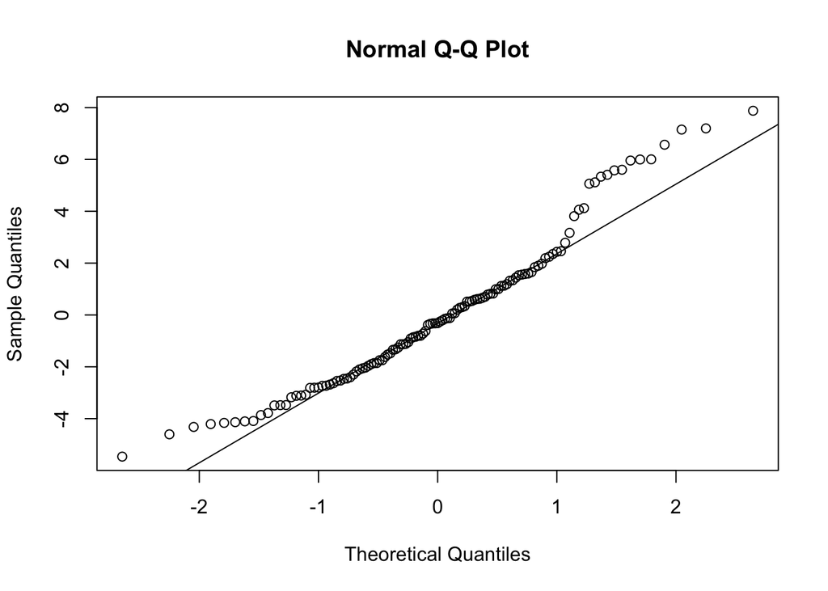

```r
residuals_M8 <- residuals(M8)
qqnorm(residuals_M8)
qqline(residuals_M8)
```

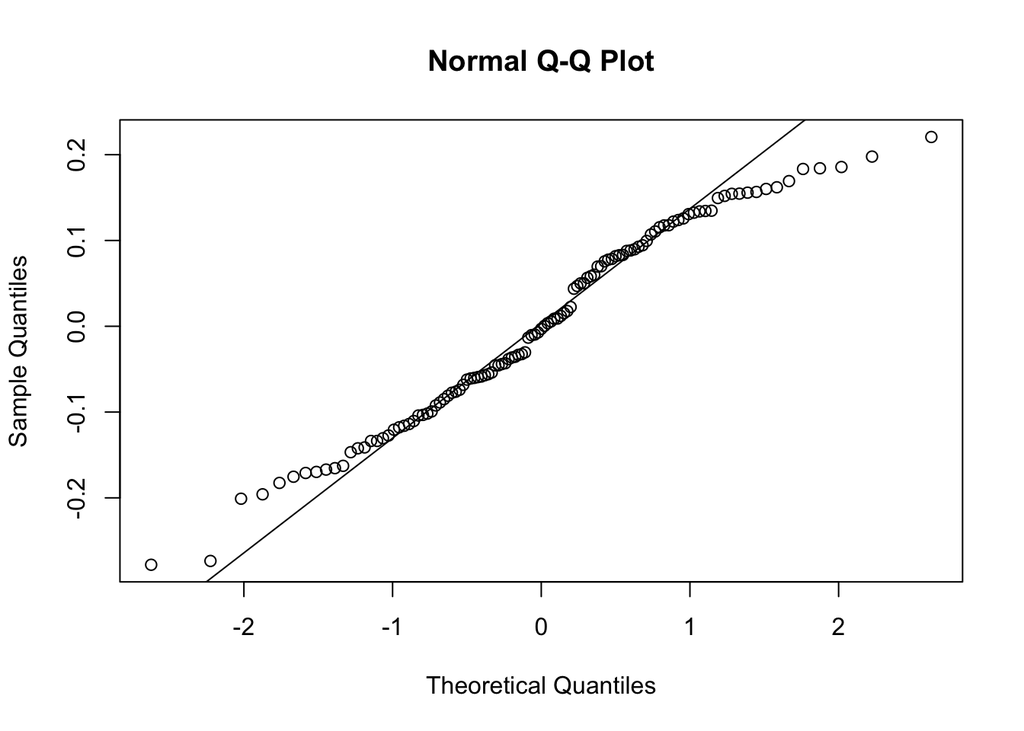

```r
residuals_M9 <- residuals(M9)
qqnorm(residuals_M9)
qqline(residuals_M9)
```

__<###Interpretation The Q-Q (Quantile-Quantile) plot is a graphical tool used to determine if the current set of data is consistent with a particular theoretical distribution (Makkonen, 2008). The result interpretation are shown below:

=> For Model 8, the quantiles of residuals in this model are plotted against the normal distribution quantiles. It can be inferred that the scatter plot of the residuals is generally normal because it goes roughly along the 45-degree line notwithstanding that there are a few variations in the upper and lower quantiles.

=> For Model 9, the quantiles of residuals in this model are plotted against the normal distribution quantiles. It can be inferred that the scatter plot of the residuals is generally normal because it goes roughly along the 45-degree line notwithstanding that there are a few variations in the upper and lower quantiles.>__

4. Generate the Scale-Location-plots for both models. Explain the logic behind the plot and intrepret the results.

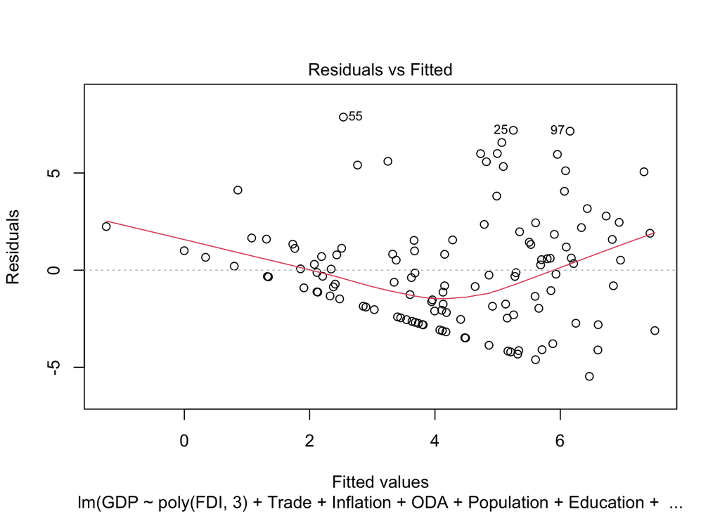

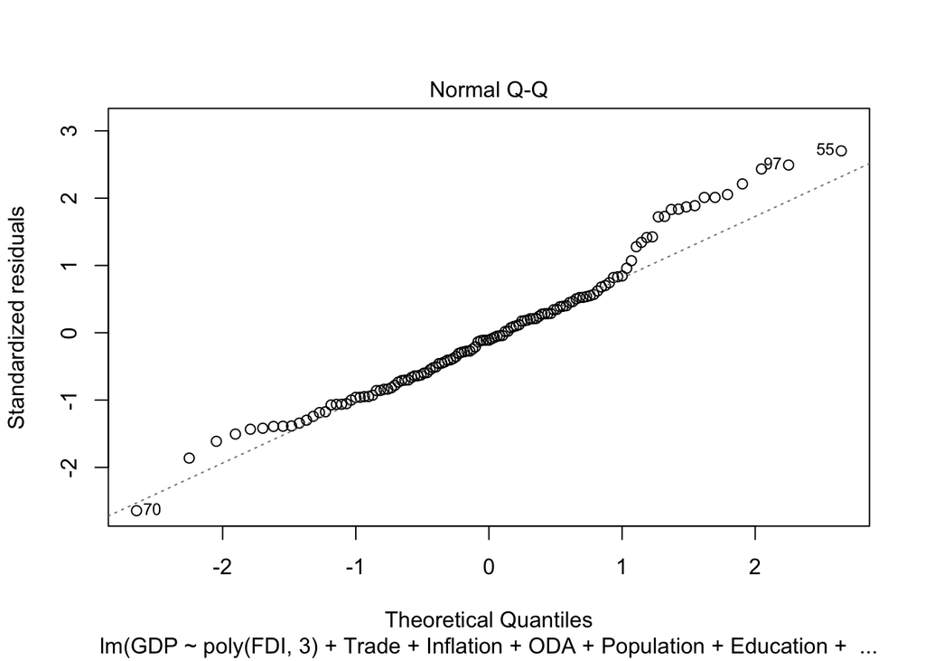

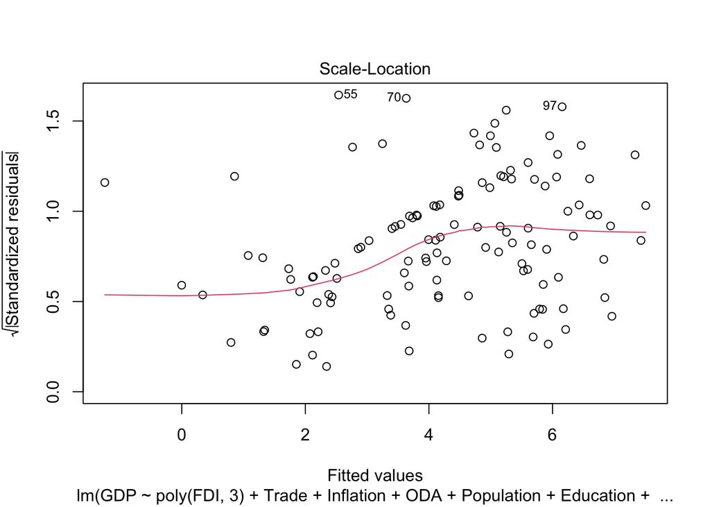

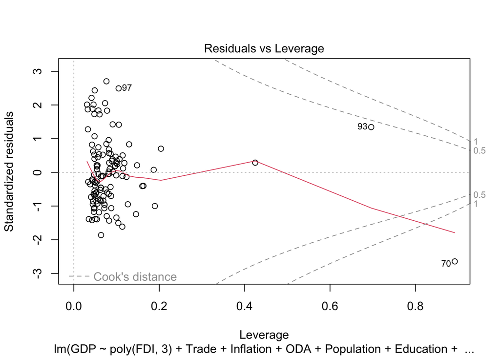

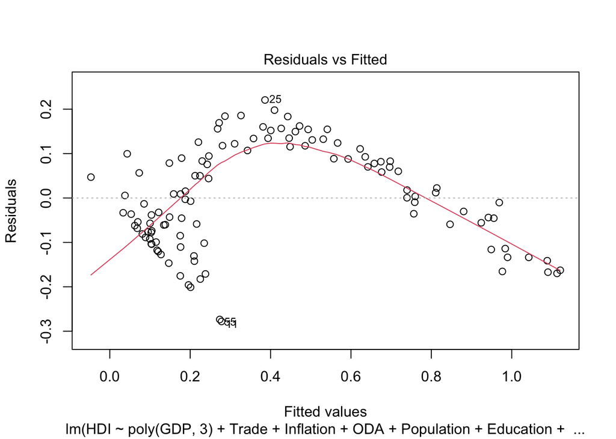

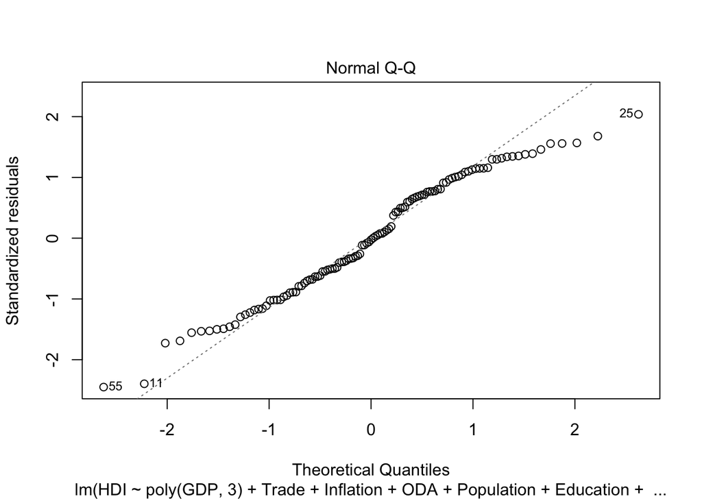

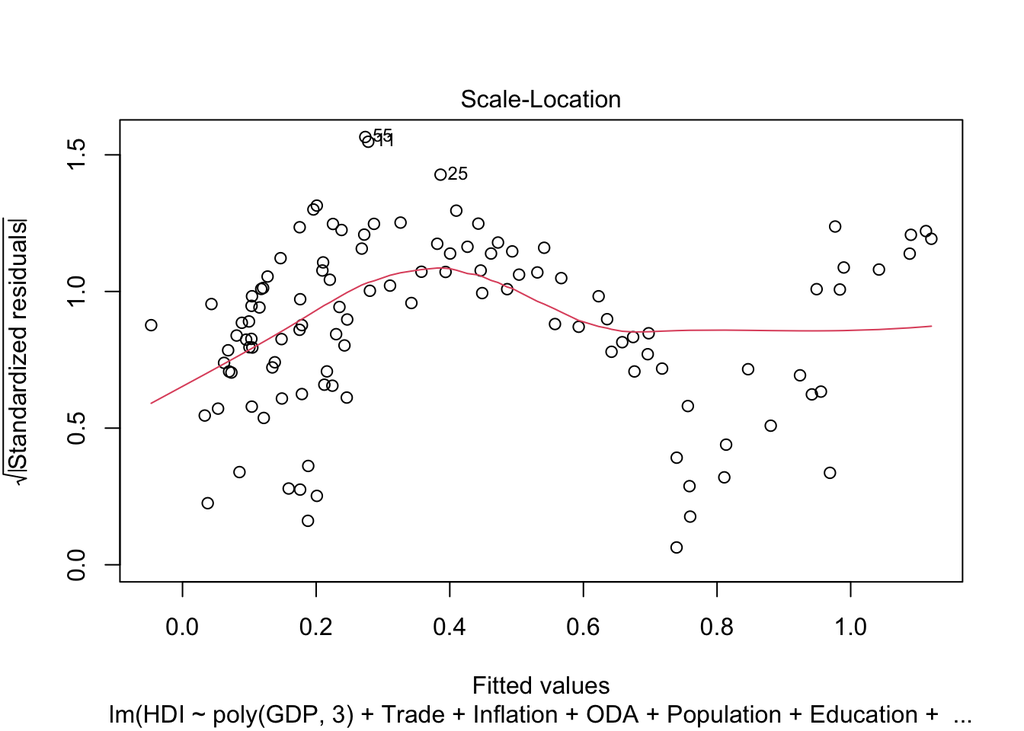

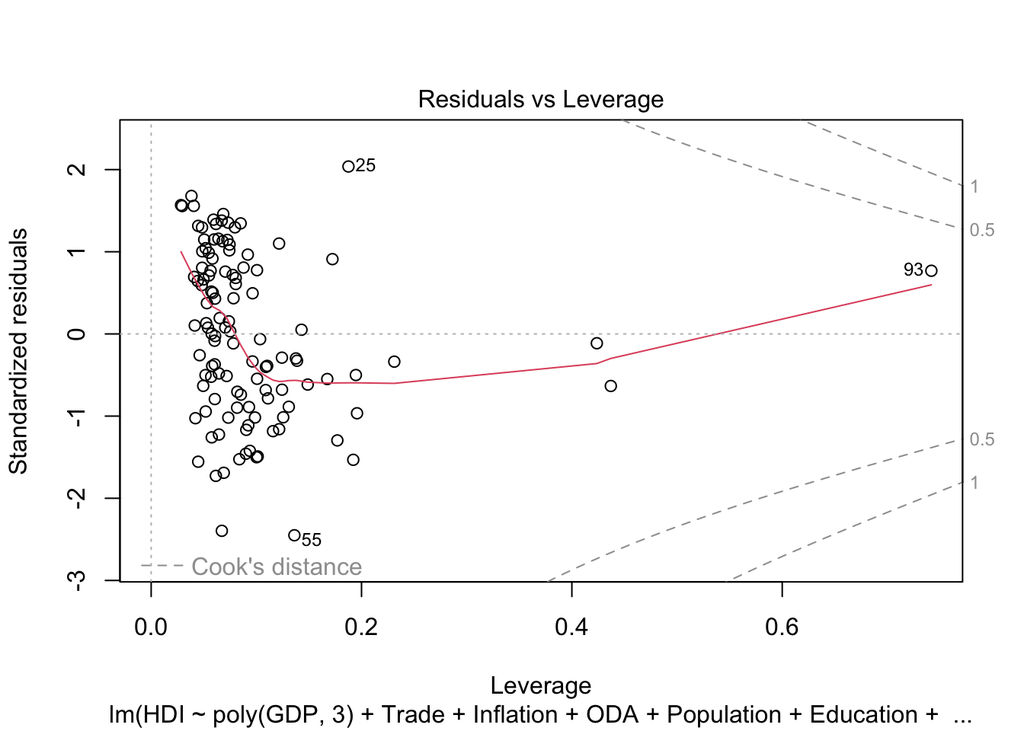

```r
{plot(M8)
plot(M9)}
```

###Test for Heteroskedasticity H0= There is no heteroskedasticity i.e our residuals are homoskedastic. H1= There is heteroskedasticity.

```r
library(lmtest)
options(scipen=999)
(bptest_result <- bptest(M8))
```

```
##
##  studentized Breusch-Pagan test
##
## data:  M8
## BP = 17.106, df = 10, p-value = 0.07206
```

```r
(bptest_results <- bptest(M9))
```

```
##
##  studentized Breusch-Pagan test
##
## data:  M9
## BP = 22.474, df = 10, p-value = 0.01286
```

__<###Interpretation Scale-Location-Plots are graphical tools used to assess homoscedasticity condition of residuals (Hodges & Atkinson, 1987). It compares the predicted values from the regression model from the normalized residuals (Hill et. al, 2018). The concept of Heteroscedasticity and Homoscedasticity is required to interpret scale-location plot results.

Heteroscedasticity occurs when the variance of error terms or residuals varies across different values of independent variables in a regression analysis (Breusch & Pagan, 1979). In scale-location-plot, if the plot shows a clear trend such as a funnel shape, fan shape, bow-tie shape, biased shape or any consistent increase or decrease in the distribution of residuals, it shows Heteroscedasticity (Hill et al, 2018).

Homoscedasticity occurs when the variance of error terms or residuals are constant across different values of independent variables in a regression analysis (Breusch & Pagan, 1979). In a scale location-plot, if the plot shows an irregular dispersion of points along a horizontal line with a roughly identical distribution, it shows homoscedasticity (Hill et al, 2018).

# References

< Barten, A. P. (1987). The Coeffecient of Determination for Regression without a Constant Term.The Practice of Econometrics, pp. 181–189.

Belsley, D. (1991). Conditioning Diagnostics: Collinearity and Weak Data in Regression. New York: Wiley. ISBN 978-0-471-52889-0

Breusch, T. S. & Pagan, A. R. (1979). A Simple Test for Heteroskedasticity and Random Coefficient Variation. Econometrica, 47 (5): 1287–1294. doi:10.2307/1911963.

Corbett, B. M. (2008). Selecting a best-fit temperature-dependent regression model for thin target HVI data. International Journal of Impact Engineering, 35(12), 1672–1677. https://doi.org/10.1016/j.ijimpeng.2008.07.024

Dancer, D., & Tremayne, A. (2005). R-squared and prediction in regression with ordered quantitative response. Journal of Applied Statistics, 32(5), 483–493. https://doi.org/10.1080/02664760500079423

Dougherty, C. (2002). Introduction to Econometrics (2nd ed.). New York: Oxford University Press. pp. 48–113. ISBN 0-19-877643-8.

Gelman, A., & Hill, J. (2006). Data analysis using regression and multilevel/hierarchical models. Cambridge University Press

Harrison, M. T. (2012). Conservative hypothesis tests and confidence intervals using importance sampling. Biometrika, 99(1), 57–69. https://doi.org/10.1093/biomet/asr079

Heiss, F. (2016). Using R for Introductory Econometrics. CreateSpace Independent Publishing Platform. http://www.urfie.net/.

Hill, R. C., Griffiths, W. E., & Lim, G. C. (2018). Principles of econometrics. New York, United States of America: John Wiley & Sons. http://principlesofeconometrics.com/poe3/poe3toc.pdf

Hodges, J. S., & Atkinson, A. C. (1987). Plots, Transformations, and Regression: An Introduction to Graphical Methods of Diagnostic Regression Analysis. Journal of the American Statistical Association, 82(398), 689. https://doi.org/10.2307/2289498

Jarque, Carlos M.; Bera, Anil K. (1980). Efficient tests for normality, homoscedasticity and serial independence of regression residuals. Economics Letters. 6 (3): 255–259. doi:10.1016/0165-1765(80)90024-5.

Kumar, T. K. (1975). Multicollinearity in Regression Analysis. Review of Economics and Statistics. 57 (3): 365–366. doi:10.2307/1923925. JSTOR 1923925.

Leatham, K. R. (2012). Problems Identifying Independent and Dependent Variables. School Science and Mathematics, 112(6), 349–358. https://doi.org/10.1111/j.1949-8594.2012.00155.x

Makkonen, L. (2008). Bringing closure to the plotting position controversy. Communications in Statistics – Theory and Methods, 37 (3): 460–467, doi:10.1080/03610920701653094, S2CID 122822135

Ramsey, J. B. (1969). Tests for Specification Errors in Classical Linear Least Squares Regression Analysis. Journal of the Royal Statistical Society, Series B. 31 (2): 350–371. JSTOR 2984219.

Zhang, J. (2002). “Powerful goodness-of-fit tests based on the likelihood ratio” (PDF). J. R. Stat. Soc. B. 64 (2): 281–294. doi:10.1111/1467-9868.00337. >

# Declaration of Authenticity

I, MSD Student Amarachi Lauren Obioha, hereby declare that the work presented herein is my own work completed without the use of any aids other than those listed. Any material from other sources or works done by others has been given due acknowledgement and listed in the reference section. Sentences or parts of sentences quoted literally are marked as quotations. The work presented herein has not been published or submitted elsewhere for assessment in the same or a similar form. I will retain a copy of this assignment until after the Board of Examiners has published the results, which I will make available on request.

This document was created by machine and is therefore valid without signature.